# 0226

```r
#####
# set up the environment
#####
# load packages
library(rethinking)
options(mc.cores = parallel::detectCores())
rstan_options(auto_write = TRUE)

# adjust the plot region for viewing on the projector in class
options(repr.plot.height=5)
```

[output not shown]

## Indexing variables within models

The ability to use indexes to refer to specific components of complex parameters is one of the biggest benefits of the probabilistic model specification we have been using all sememster. As we saw in the slides, indices (represented there by subscripts) allowed for easy specification of fixed-effects models and, more imporantly, hierarchical (mulilevel) models.

To see how this translates into R code, we will load the Tennesee STAR data and get a subset of 30 classes of grade-one students.

```r
d <- read.csv("https://mcmahanp.github.io/soci620/data/t_star_student_grade1.csv")
# take a look at the data to see how it's structured
head(d)
```

| student_id | teacher_id | class_type | class_size | born | female | race_ethnicity | re_white | re_black | re_asian | re_hispanic | re_native_american | re_other | reading_score | math_score | listening_score |
| --- | --- | --- | --- | --- | --- | --- | --- | --- | --- | --- | --- | --- | --- | --- | --- |
| 1 | 1 | 3 | 23 | 1979.058 | FALSE | White | TRUE | FALSE | FALSE | FALSE | FALSE | FALSE | 516 | 578 | 601 |
| 2 | 2 | 2 | 22 | 1980.404 | FALSE | White | TRUE | FALSE | FALSE | FALSE | FALSE | FALSE | 451 | 507 | 584 |
| 3 | 3 | 2 | 21 | 1979.307 | TRUE | Black | FALSE | TRUE | FALSE | FALSE | FALSE | FALSE | 483 | 526 | 529 |
| 4 | 4 | 3 | 21 | 1980.322 | FALSE | Black | FALSE | TRUE | FALSE | FALSE | FALSE | FALSE | 516 | 505 | 556 |
| 5 | 4 | 3 | 21 | 1978.416 | TRUE | Black | FALSE | TRUE | FALSE | FALSE | FALSE | FALSE | 433 | 463 | 504 |
| 6 | 5 | 3 | 29 | 1980.648 | TRUE | Black | FALSE | TRUE | FALSE | FALSE | FALSE | FALSE | 444 | 542 | 543 |

```r
# get rid of cases with no reading score
d <- d[!is.na(d$reading_score),]

# pick 30 random classes
# list of all distinct teacher ids
all_teacher_ids <- unique(d$teacher_id)
# get 30 of them
subsamp_teacher_ids <- sample(all_teacher_ids,30)
# subset d
d <- d[d$teacher_id %in% subsamp_teacher_ids,]
head(d)
```

|  | student_id | teacher_id | class_type | class_size | born | female | race_ethnicity | re_white | re_black | re_asian | re_hispanic | re_native_american | re_other | reading_score | math_score | listening_score |
| --- | --- | --- | --- | --- | --- | --- | --- | --- | --- | --- | --- | --- | --- | --- | --- | --- |
| 6 | 6 | 5 | 3 | 29 | 1980.648 | TRUE | Black | FALSE | TRUE | FALSE | FALSE | FALSE | FALSE | 444 | 542 | 543 |
| 13 | 13 | 12 | 2 | 24 | 1979.521 | TRUE | White | TRUE | FALSE | FALSE | FALSE | FALSE | FALSE | 503 | 538 | 565 |
| 18 | 18 | 16 | 1 | 18 | 1980.301 | FALSE | Black | FALSE | TRUE | FALSE | FALSE | FALSE | FALSE | 454 | 523 | 559 |
| 26 | 26 | 22 | 2 | 23 | 1980.656 | TRUE | Black | FALSE | TRUE | FALSE | FALSE | FALSE | FALSE | 482 | 520 | 538 |
| 50 | 50 | 41 | 2 | 22 | 1979.647 | FALSE | White | TRUE | FALSE | FALSE | FALSE | FALSE | FALSE | 468 | 532 | 546 |
| 57 | 57 | 5 | 3 | 29 | 1980.036 | FALSE | Black | FALSE | TRUE | FALSE | FALSE | FALSE | FALSE | 524 | 562 | 606 |

1. 557

2. 16

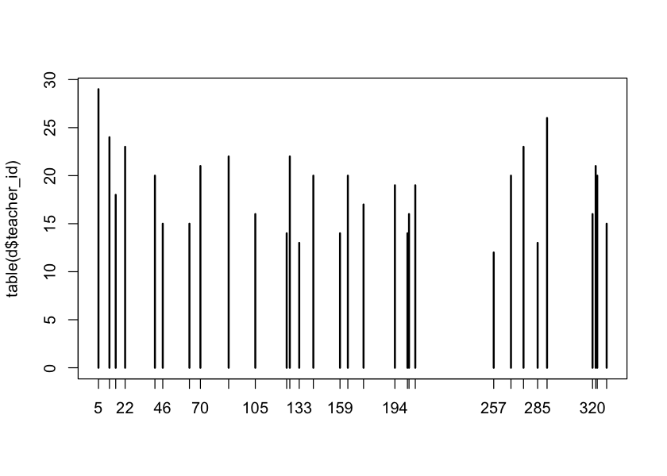

```r
dim(d)
plot(table(d$teacher_id))
```

### Re-indexing

One of the tricky parts about using indexes in your model specification is generating those in a way that your model can understand. Right now the `teacher_id` takes on 30 distinct values, but they are non-consecutive, with the largest being over 300 (*probably*—remember that our subsample was random!). R will need these indexes to refer to specific items in a list, so the index will need to start at 1 and continue up to the number of classes we have (30) without skipping any numbers.

This kind of index can be a little tricky to construct in R, so here is a simple function that should work in most cases:

```r
reindex_1 <- function(x){
    ####
    # re-index an id x to exactly 1:length(x)
    ####
    # first find unique values of original index, dropping NAs
    x_old <- unique(as.character(x))
    x_old <- x_old[!is.na(x_old)]
    # make a new index that is exactly 1:length(x)
    x_new <- seq(length(x_old))
    # use the old index as the names of the new index to create a mapping between them
    names(x_new) <- x_old
    # grab individual items from x_new, one for each item in x
    return(x_new[as.character(x)])
}
```

```r
# make a new variable `class_id` that indexes classes in this way
d$class_id <- reindex_1(d$teacher_id)

# compare in a cross-tab to see what happened
table(d$class_id,d$teacher_id)
```

```
      5 12 16 22 41 46 63 70 88 105 125 127 133 142 159 164 174 194 202 203 207
  1  29  0  0  0  0  0  0  0  0   0   0   0   0   0   0   0   0   0   0   0   0
  2   0 24  0  0  0  0  0  0  0   0   0   0   0   0   0   0   0   0   0   0   0
  3   0  0 18  0  0  0  0  0  0   0   0   0   0   0   0   0   0   0   0   0   0
  4   0  0  0 23  0  0  0  0  0   0   0   0   0   0   0   0   0   0   0   0   0
  5   0  0  0  0 20  0  0  0  0   0   0   0   0   0   0   0   0   0   0   0   0
  6   0  0  0  0  0 15  0  0  0   0   0   0   0   0   0   0   0   0   0   0   0
  7   0  0  0  0  0  0 15  0  0   0   0   0   0   0   0   0   0   0   0   0   0
  8   0  0  0  0  0  0  0 21  0   0   0   0   0   0   0   0   0   0   0   0   0
  9   0  0  0  0  0  0  0  0 22   0   0   0   0   0   0   0   0   0   0   0   0
  10  0  0  0  0  0  0  0  0  0  16   0   0   0   0   0   0   0   0   0   0   0
  11  0  0  0  0  0  0  0  0  0   0  14   0   0   0   0   0   0   0   0   0   0
  12  0  0  0  0  0  0  0  0  0   0   0  22   0   0   0   0   0   0   0   0   0
  13  0  0  0  0  0  0  0  0  0   0   0   0  13   0   0   0   0   0   0   0   0
  14  0  0  0  0  0  0  0  0  0   0   0   0   0  20   0   0   0   0   0   0   0
```

[output cut: 48 more lines]

### Fixed-effects models

With this index constructed, we are ready to specify a fixed-effects model. We will use the simple fixed-intercepts model from the slides:

$$S_{ik} \sim \mathrm{Norm}(\mu_{ik},\sigma)\\ \mu_{ik} = \alpha_k\\ \\ \alpha_k \sim \mathrm{Norm}(500,100)\\ \sigma \sim \mathrm{Unif}(0,100)$$

```r
m_fe <- alist(
    reading_score ~ dnorm(mu,sigma),
    mu <- a[class_id],
    a[class_id] ~ dnorm(500,100),
    sigma ~ dunif(0,100)
)
```

We estimate this model using `map2stan()`. Although pure fixed-effects models like this can still be estimted using `map()`, most multilevel models cannot. It is best to be consistent and use `map2stan()` for all of them.

```r
fit_fe <- map2stan(m_fe,data=d)
precis(fit_fe,prob=.9)
```

```
[ 1000 / 1000 ]
```

```
30 vector or matrix parameters omitted in display. Use depth=2 to show them.
```

```
       Mean StdDev lower 0.9 upper 0.9 n_eff Rhat
sigma 47.68   1.58     44.98      50.2  2999    1
```

Calling `precis` like we usually do gives us estimates only for `sigma` with a notice that we're not seeing all of our parameters. This is because `a` is actually a collection of 30 estimates, so it won't fit into the same kind of output. Simply specifying `depth=2` will let us see "inside" `a`.

```r
precis(fit_fe, prob=0.9, depth=2)
```

```
        Mean StdDev lower 0.9 upper 0.9 n_eff Rhat
a[1]  467.29   8.39    453.03    480.50  2765    1
a[2]  546.66   9.50    531.78    561.24  3112    1
a[3]  522.20  11.32    503.48    540.57  2241    1
a[4]  467.82  10.43    450.43    483.51  2489    1
a[5]  516.33  10.50    499.63    533.29  2140    1
a[6]  516.00  12.52    497.53    537.83  2869    1
a[7]  568.75  11.52    549.09    587.12  2645    1
a[8]  491.68   9.94    475.49    508.40  3490    1
a[9]  549.41   9.27    535.22    565.28  2446    1
a[10] 479.06  11.59    460.01    496.36  2492    1
a[11] 568.22  12.91    547.11    587.98  3543    1
a[12] 491.38   9.82    476.23    508.29  2730    1
a[13] 558.87  13.46    537.13    580.52  2100    1
a[14] 522.04  10.62    505.64    540.25  3131    1
a[15] 498.04  12.98    477.10    520.35  3053    1
a[16] 534.32  10.25    517.64    551.44  2600    1
a[17] 463.85  11.38    444.68    481.85  3895    1
a[18] 511.67  11.01    495.11    531.02  3781    1
a[19] 492.93  12.68    472.45    514.96  1954    1
a[20] 536.99  11.65    517.43    555.63  3197    1
a[21] 509.14  10.86    492.12    527.47  3028    1
a[22] 531.41  13.60    507.96    551.98  2135    1
a[23] 498.81  10.56    480.96    515.67  3368    1
a[24] 536.94   9.80    520.24    552.69  1905    1
a[25] 597.14  13.42    576.84    619.61  2369    1
a[26] 521.71   9.65    504.36    535.75  3155    1
a[27] 504.30  12.55    484.67    525.21  1525    1
a[28] 549.72   9.98    534.50    567.49  2175    1
a[29] 526.96  10.31    510.65    543.83  2051    1
a[30] 524.54  11.89    502.39    540.89  3261    1
sigma  47.68   1.58     44.98     50.20  2999    1
```